# The Bootstrap (Part 2)

Stanford University, Spring 2016, STATS 205

## Previous Lecture

- Introduced bootstrap
- Looked at couple of example applications:
  - confidence intervals
  - hypotheses testing
- Two sources of errors:
  - sampling variability
  - bootstrap resampling variability
- Complete enumerations for exhaustive bootstrap

## Today

- Example comparison between boostrap using
  - Monte Carlo simulations (\(B\) is large)
  - exhaustive bootstrap (\(B\) is infinity)
- Smarter way to enumerate boostrap samples using Gray codes
- Exploring the tails of a bootstrap distribution

## Law Schools Example

```r
library(bootstrap); data(law); t(law)
```

```
##        1   2   3   4   5   6   7   8   9  10  11  12  13  14  15
## LSAT 576 635 558 578 666 580 555 661 651 605 653 575 545 572 594
## GPA  339 330 281 303 344 307 300 343 336 313 312 274 276 288 296
```

## Law Schools Example

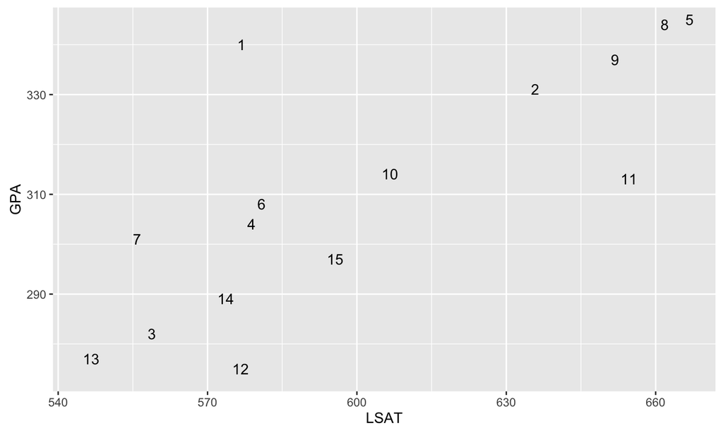

## Law Schools Example

- Sample correlation coefficient:

```
## [1] 0.7763745
```

- How accurate is this estimate. Let's look at the bootstrap samples:

```r
draw.bootstrap.sample = function() {
  n = dim(law)[1]
  ind = sample(n,replace = TRUE)
  return(cor(law[ind,]$LSAT,law[ind,]$GPA))
}
B = 40000
thetastar = replicate(B,draw.bootstrap.sample())
```

## Law Schools Example

Evaluate the correlation coefficient using a Monte Carlo simulation:

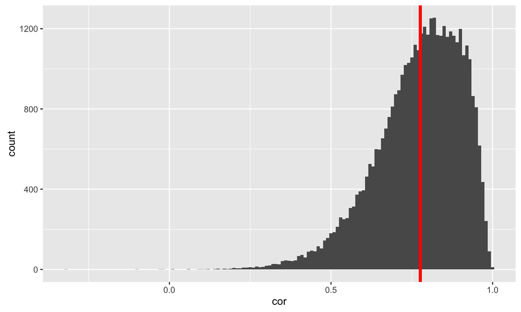

## Law Schools Example

Create matrix of all \(\binom{2n-1}{n-1}\) enumerations:

```r
library(partitions)
n = 15
allCompositions = compositions(n,n)
```

```r
allCompositions[,1:10]
```

```
##       [,1] [,2] [,3] [,4] [,5] [,6] [,7] [,8] [,9] [,10]
##  [1,]   15   14   13   12   11   10    9    8    7     6
##  [2,]    0    1    2    3    4    5    6    7    8     9
##  [3,]    0    0    0    0    0    0    0    0    0     0
##  [4,]    0    0    0    0    0    0    0    0    0     0
##  [5,]    0    0    0    0    0    0    0    0    0     0
##  [6,]    0    0    0    0    0    0    0    0    0     0
##  [7,]    0    0    0    0    0    0    0    0    0     0
##  [8,]    0    0    0    0    0    0    0    0    0     0
##  [9,]    0    0    0    0    0    0    0    0    0     0
## [10,]    0    0    0    0    0    0    0    0    0     0
## [11,]    0    0    0    0    0    0    0    0    0     0
## [12,]    0    0    0    0    0    0    0    0    0     0
## [13,]    0    0    0    0    0    0    0    0    0     0
## [14,]    0    0    0    0    0    0    0    0    0     0
## [15,]    0    0    0    0    0    0    0    0    0     0
```

## Law Schools Example

Check number of compositions:

```r
library(assertthat)
nCompositions = dim(allCompositions)[2]
nCompositions
```

```
## [1] 77558760
```

```r
# Check if we get the same value as in theory
nCompositionsTheory = choose(2*n-1,n-1)
if(!assert_that(nCompositions == nCompositionsTheory)) {
  print("there is a problem with the number of compositions")
} else {
  print("the number of compositions is correct")
}
```

```
## [1] "the number of compositions is correct"
```

## Law Schools Example

Evaluate the correlation coefficient for all \(\binom{2n-1}{n-1}\) bootstrap samples.

```r
library(parallel)
if(!file.exists("enumData.Rdata")) {
  ptm = proc.time()
  enumData = mclapply(1:nCompositions, function(i) {
    ind = allCompositions[,i]
    law.list = lapply(1:n,function(j) matrix(rep(law[j,],ind[j]),ncol = 2 ,byrow = TRUE))
    newLaw = do.call(rbind, law.list)
    c(cor(unlist(newLaw[,1]),unlist(newLaw[,2])),dmultinom(ind,prob = rep(1,n)))
    }, mc.cores = 4)
  proc.time() - ptm
  enumData = t(simplify2array(enumData))
  colnames(enumData) = c("cor","weight")
  save(enumData,file = "enumData.Rdata")
} else {
  load("enumData.Rdata")
}
```

## Law Schools Example

Same plot as before but now with all bootstrap samples:

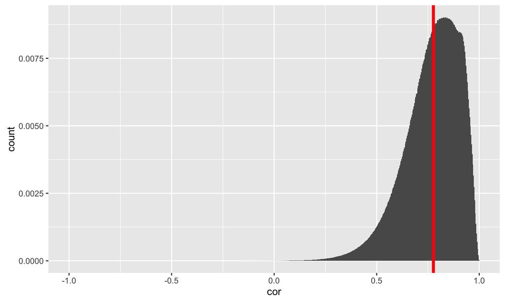

## Law Schools Example

Use the library parallel to speedup computations

```r
library(parallel)
enumData = mclapply(1:nCompositions, function(i) { ... }, mc.cores = 4 )
```

- On a laptop with 4 cores this takes about 5 hours to compute
- We can speedup enumeration by changing only one coordinates at the time using Gray codes
- For example, if our estimate is the sample mean for \(n = 3\)
  - \(s(\boldsymbol{x}^{*1}) = ( x_1 + x_2 + x_3)/3\)
  - \(s(\boldsymbol{x}^{*2}) = ( x_1 + x_2 + x_2)/3\)
- To calculate \(s(\boldsymbol{x}^{*2})\) from \(s(\boldsymbol{x}^{*1})\)
  - \(s(\boldsymbol{x}^{*1}) - x_3/3 + x_2/3\)

## Speedup for Enumerations using Gray Codes

- Gray codes are ordered lists of binary \(n\)-tuples
- They are ordered so that success values only differ in a single space
- For instance, for \(n = 3\), the list is:  
  `000, 001, 011, 010, 110, 111, 101, 100`
- Notice, a computer scientist might intuitively want to write this:  
  `000, 001, 010, 011, 100, 101, 110, 111`
- However, this sequence differes in many spaces
- Better than trying to reorder the wrong elements, we can define recursive algorithm to generate a valid list

## Speedup for Enumerations using Gray Codes

- Start with a list with two entries `0,1`
- Get two list:
  - put a zero before each entry in \(L_n\)
  - put a one before each entry in \(L_n\)
- To get \(L_{n+1}\) concatenate the two list by first followed by second in reversed order
- So to move from \(L_1\) to \(L_2\)  
  `00, 01`  
  `10, 11`
- and concatenate  
  `00, 01, 11, 10`
- repeat…

## Speedup for Enumerations using Gray Codes

- We can also just add one successor at the time
- As we saw before, a computer scientist would encode an integer as \(m = \sum \epsilon_i 2^i\) using the binary sequence \[ \dots \, \epsilon_3 \, \epsilon_2 \, \epsilon_1 \, \epsilon_0 \]
- This can be mapped to gray codes \[ \dots \, e_3 \, e_2 \, e_1 \, e_0 \] using \(e_i = \epsilon_i + \epsilon_{i+1} \, (\bmod 2) \text{ for } (i = 0,1,2,\dots)\)

## Speedup for Enumerations using Gray Codes

- When \(n = 4\), the integer 7 in binary code is `0111` and using the mapping  
  \(e_0 = 1 + 1 = 0\)  
  \(e_1 = 1 + 1 = 0\)  
  \(e_2 = 1 + 0 = 1\)  
  \(e_3 = 0 + 0 = 0\)
- we get the corresponding gray code `0100`
- Next, integer 8 in binary code is `1000` and using the mapping  
  \(e_0 = 0 + 0 = 0\)  
  \(e_1 = 0 + 0 = 0\)  
  \(e_2 = 0 + 1 = 1\)  
  \(e_3 = 1 + 0 = 1\)
- we get the corresponding gray code `1100`

## Exploring the Tails of a Bootstrap Distribution

- Using Markov chain Monte Carlo (MCMC) to inject a small amount of randomness (something between Monte Carlo and complete enumerations)
- We will use MCMC to deriving large deviations estimate such as \(P( T \ge t)\)
- To see how it works, we let's have a look at the Metropolis algorithm
- Consider a the finite sample space
- Think of it as a state space, where each outcome corresponds to a state
- Metropolis can sample from an unormalized probability \(\pi(x)\) on finite state space \(\mathcal{X}\)
- Define a Markov transition matrix \(J(x,y)\) that defines nonzero probabilities of moving from \(x\) to \(y\) and \(y\) to \(x\)
- Metropolis changes \(J(x,y)\) to a new matrix \(K(x,y)\) that corresponds to a possibly unnormalized version of \(\pi(x)\)

## Exploring the Tails of a Bootstrap Distribution

- Recipe:
  - Pick initial point in sample space \(x_0\)
  - Pick potential next move from \(J(x,y)\) with \(J(x,y) > 0\) and \(J(y,x) > 0\)
  - Evaluate \[A(x,y) = \frac{\pi(y)J(y,x)}{\pi(x)J(x,y)}\]
  - If \(A(x,y) \ge 1\) move to \(y\)
  - If \(A(x,y) < 1\) flip a coing with this success probability
    - and move to \(y\) if success
    - otherwise stay at \(x\)

## Exploring the Tails of a Bootstrap Distribution

- We can write this in matrix form \[ K(x,y) = \begin{cases} J(x, y) & \text{if } x \ne y, A(x, y) ≥ 1 \\ J(x, y)A(x, y) & \text{if } x \ne y, A(x, y) < 1 \\ J(x, y) + \sum_{z:A(x,z)<1} J(x, z)(1 − A(x, z)) & \text{if } x = y \end{cases} \]
- Then we can use the Fundamental Theorem of Markov Chains to prove that \[ K^n(x, y) \to \pi(y) \text{ for each } x,y \in \mathcal{X} \]
- or in other words, the matrix \(K^n = K^1 K^2 \cdots K^n\) converges to a matrix \[\pi K = \lambda \pi \leftrightarrow \pi K = \pi\] with one left eigenvector \(\pi\) and one eigenvalue \(\lambda = 1\)

## Exploring the Tails of a Bootstrap Distribution

- To sample from \(\pi\), apply \(J\) to the left of the current sample position \(x_t\)
- This will give us the next sample \(x_{t+1}\)
- A nice introduction to MCMC is [here](https://math.uchicago.edu/~shmuel/Network-course-readings/MCMCRev.pdf)

## Exploring the Tails of a Bootstrap Distribution

We construct a Markov chain to sample from \(P( T \ge t)\):

- Pick \(I\) between \(1 \le I \le n\) uniformly, and
- Replace \(x^*_I\) with new value from origin data \(\{ x_1, x_2, \dots, x_n \}\)
- If new sample vector \(\tilde{\boldsymbol{x}}^*\) satisfies \(T(\tilde{\boldsymbol{x}}^*) \ge t\) then change is made
- otherwise the chain stays at previous sample vector

## Exploring the Tails of a Bootstrap Distribution

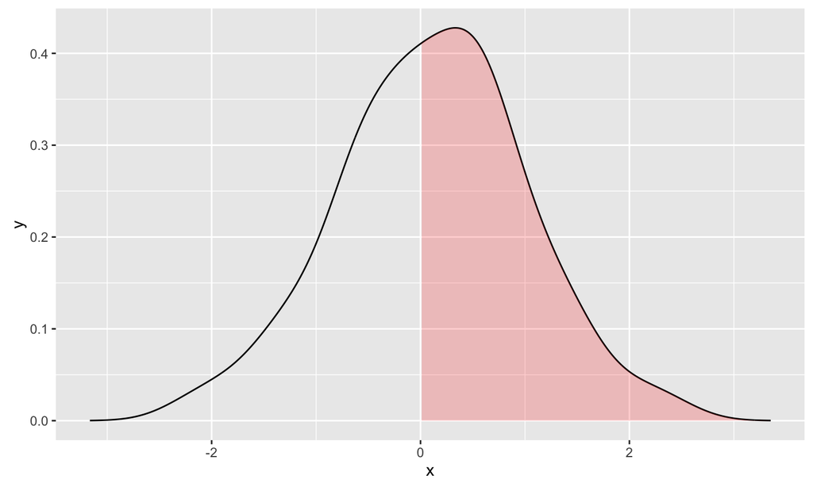

## Exploring the Tails of a Bootstrap Distribution

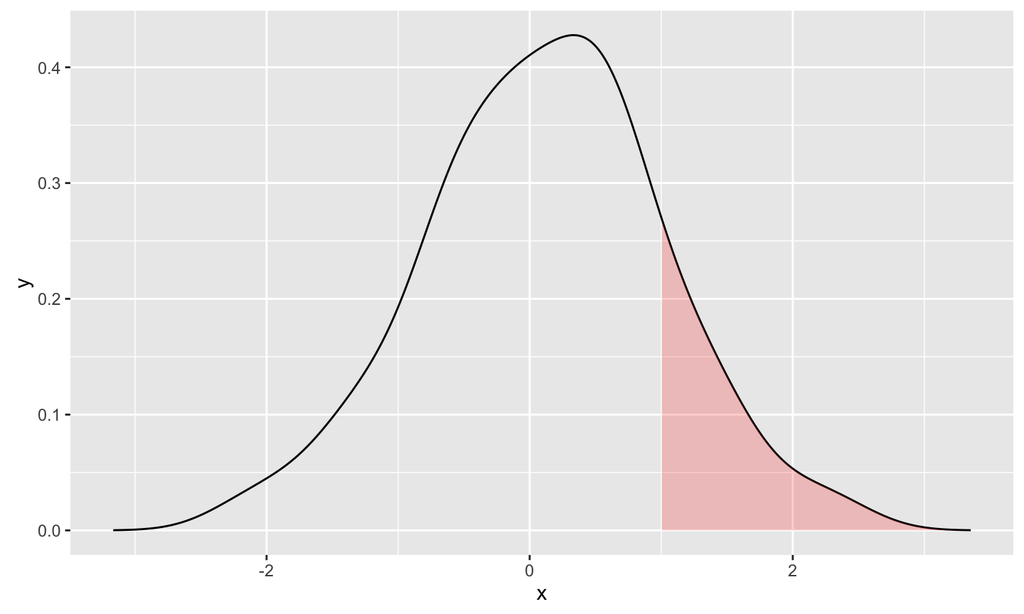

## Exploring the Tails of a Bootstrap Distribution

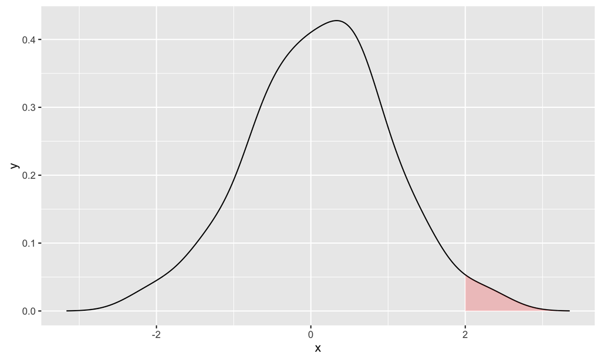

## Exploring the Tails of a Bootstrap Distribution

Then to estimate \(P( T \ge t)\):

- Choose a grid \(t_0 < t_1 < \dots < t_l < t\) with \(t_0\) chosen in the middle of distribution of \(T\) and \(t_i\) chosen so that \(P(T \ge t_{i+1} | T \ge t_i)\) is not too small
- Estimate \(P( T \ge t_0 )\) by ordinary Monte Carlo
- Estimate \(P( T \ge t_1 | T \ge t_0)\) by running the Markov chain on \(\{ \tilde{\boldsymbol{x}}^*: T(\tilde{\boldsymbol{x}}^*) \ge t_0) \}\) and count what proportion of values satisfy the constrain \(T \ge t_1\)
- Multiplying these estimates gives the conditional probability: \[ \widehat{P}(T \ge t) = \widehat{P}(T \ge t_0) \widehat{P}(T \ge t_1 | T \ge t_0) \cdots \widehat{P}(T \ge t | T \ge t_l) \] and joint probability \(\widehat{P}(T \ge t) = \widehat{P}(T \ge t_0,T \ge t_1, \dots, T \ge t_l, T \ge t)\)

## Theoretical Underpinnings of the Bootstrap

For background on statistical functionals and asymptotics of the boostrap:

- Lehmann 1999  
  *Elements of Large-Sample Theory*  
  Chapter 6  
  Stanford library link
- Van der Vaart 1998  
  *Asymptotic Statistics*  
  Chapter 23  
  Stanford library link